# Chapter 12: Multivariate Regression

Today’s class will be based on [Chapter 12: “Multiple Regression”](https://davidkane9.github.io/PPBDS/12-multiple-regression.html). Have you read it? We will be using data on college characteristics from the IPEDS Database and the Scorecard created by the Department of Education, gathered via the [Opportunity Insights](https://opportunityinsights.org/) project. The codebook with explanations for each variable is [here](https://opportunityinsights.org/wp-content/uploads/2018/04/Codebook-MRC-Table-10.pdf). We will be trying to figure out what characteristics of a college are associated with the 2011 median income of students, `earnings`, 10 years after they graduate. The other data — `faculty`, the average faculty salary; `sat`, the average SAT score; and `price`, tuition — is measured in 2001.

### Scene 1

**Prompt:** To begin, we are going to go through the three common steps of exploring a new dataset: 1) looking at the raw data, 2) computing summary statistics, and 3) creating visualizations of the data. Scene one will focus on the first two steps. Useful commands to use here: `glimpse()`,`sample_n`, and `skim` (from the skimr package). What observations are surprising? Do you believe this data? What should you check out?

Data summary

| Name | x |
| --- | --- |
| Number of rows | 797 |
| Number of columns | 9 |
| _______________________ |  |
| Column type frequency: |  |
| character | 2 |
| numeric | 7 |
| ________________________ |  |
| Group variables | None |

**Variable type: character**

| skim_variable | n_missing | complete_rate | min | max | empty | n_unique | whitespace |
| --- | --- | --- | --- | --- | --- | --- | --- |
| name | 0 | 1 | 11 | 141 | 0 | 797 | 0 |
| tier_name | 0 | 1 | 8 | 45 | 0 | 10 | 0 |

**Variable type: numeric**

| skim_variable | n_missing | complete_rate | mean | sd | p0 | p25 | p50 | p75 | p100 | hist |
| --- | --- | --- | --- | --- | --- | --- | --- | --- | --- | --- |
| tier | 0 | 1 | 5.27 | 1.46 | 1.00 | 5.00 | 6.00 | 6.00 | 10.0 | ▁▁▇▁▁ |
| type | 0 | 1 | 1.69 | 0.48 | 1.00 | 1.00 | 2.00 | 2.00 | 3.0 | ▃▁▇▁▁ |
| public | 0 | 1 | 0.32 | 0.47 | 0.00 | 0.00 | 0.00 | 1.00 | 1.0 | ▇▁▁▁▃ |
| earnings | 0 | 1 | 45129.97 | 10694.32 | 25500.00 | 38400.00 | 43200.00 | 49200.00 | 116400.0 | ▇▆▁▁▁ |
| sat | 0 | 1 | 1080.27 | 128.87 | 775.00 | 990.00 | 1060.00 | 1160.00 | 1520.0 | ▂▇▆▂▁ |
| faculty | 0 | 1 | 55207.37 | 13491.15 | 22043.62 | 46128.28 | 52828.56 | 63393.43 | 116117.4 | ▂▇▃▁▁ |
| price | 0 | 1 | 12168.56 | 7214.09 | 1376.00 | 4160.00 | 12950.00 | 17336.00 | 26746.0 | ▇▃▇▅▃ |

```
##      name                tier         tier_name              type
##  Length:797         Min.   : 1.000   Length:797         Min.   :1.000
##  Class :character   1st Qu.: 5.000   Class :character   1st Qu.:1.000
##  Mode  :character   Median : 6.000   Mode  :character   Median :2.000
##                     Mean   : 5.266                      Mean   :1.691
##                     3rd Qu.: 6.000                      3rd Qu.:2.000
##                     Max.   :10.000                      Max.   :3.000
##      public          earnings           sat          faculty
##  Min.   :0.0000   Min.   : 25500   Min.   : 775   Min.   : 22044
##  1st Qu.:0.0000   1st Qu.: 38400   1st Qu.: 990   1st Qu.: 46128
##  Median :0.0000   Median : 43200   Median :1060   Median : 52829
##  Mean   :0.3187   Mean   : 45130   Mean   :1080   Mean   : 55207
##  3rd Qu.:1.0000   3rd Qu.: 49200   3rd Qu.:1160   3rd Qu.: 63393
##  Max.   :1.0000   Max.   :116400   Max.   :1520   Max.   :116117
##      price
##  Min.   : 1376
##  1st Qu.: 4160
##  Median :12950
##  Mean   :12169
##  3rd Qu.:17336
##  Max.   :26746
```

Data summary

| Name | x |
| --- | --- |
| Number of rows | 797 |
| Number of columns | 9 |
| _______________________ |  |
| Column type frequency: |  |
| character | 2 |
| numeric | 7 |
| ________________________ |  |
| Group variables | None |

**Variable type: character**

| skim_variable | n_missing | complete_rate | min | max | empty | n_unique | whitespace |
| --- | --- | --- | --- | --- | --- | --- | --- |
| name | 0 | 1 | 11 | 141 | 0 | 797 | 0 |
| tier_name | 0 | 1 | 8 | 45 | 0 | 10 | 0 |

**Variable type: numeric**

| skim_variable | n_missing | complete_rate | mean | sd | p0 | p25 | p50 | p75 | p100 | hist |
| --- | --- | --- | --- | --- | --- | --- | --- | --- | --- | --- |
| tier | 0 | 1 | 5.27 | 1.46 | 1.00 | 5.00 | 6.00 | 6.00 | 10.0 | ▁▁▇▁▁ |
| type | 0 | 1 | 1.69 | 0.48 | 1.00 | 1.00 | 2.00 | 2.00 | 3.0 | ▃▁▇▁▁ |
| public | 0 | 1 | 0.32 | 0.47 | 0.00 | 0.00 | 0.00 | 1.00 | 1.0 | ▇▁▁▁▃ |
| earnings | 0 | 1 | 45129.97 | 10694.32 | 25500.00 | 38400.00 | 43200.00 | 49200.00 | 116400.0 | ▇▆▁▁▁ |
| sat | 0 | 1 | 1080.27 | 128.87 | 775.00 | 990.00 | 1060.00 | 1160.00 | 1520.0 | ▂▇▆▂▁ |
| faculty | 0 | 1 | 55207.37 | 13491.15 | 22043.62 | 46128.28 | 52828.56 | 63393.43 | 116117.4 | ▂▇▃▁▁ |
| price | 0 | 1 | 12168.56 | 7214.09 | 1376.00 | 4160.00 | 12950.00 | 17336.00 | 26746.0 | ▇▃▇▅▃ |

### Scene 2

**Prompt:** What’s the correlation between the average faculty salary in 2001 and the median income of students 10 years after entering? What’s the correlation between the average SAT scores in 2001 and the median income of students 10 years after entering? Find these by doing two separate correlations first, and then making a correlation matrix (instructions in the book). Hint: Make sure to omit all missing pairs from the two variables while finding the correlation.

```
## # A tibble: 1 x 1
##   correlation
##         <dbl>
## 1       0.674
```

```
## # A tibble: 1 x 1
##   correlation
##         <dbl>
## 1       0.604
```

```
##           earnings       sat   faculty
## earnings 1.0000000 0.6041897 0.6737729
## sat      0.6041897 1.0000000 0.6359926
## faculty  0.6737729 0.6359926 1.0000000
```

### Scene 3

**Prompt:** Visualize the relationships between the outcome variable (`earnings`) and the two key numerical explanatory variables (`faculty` and `sat`), one at a time. Create a ggplot for each showing the line of best fit.

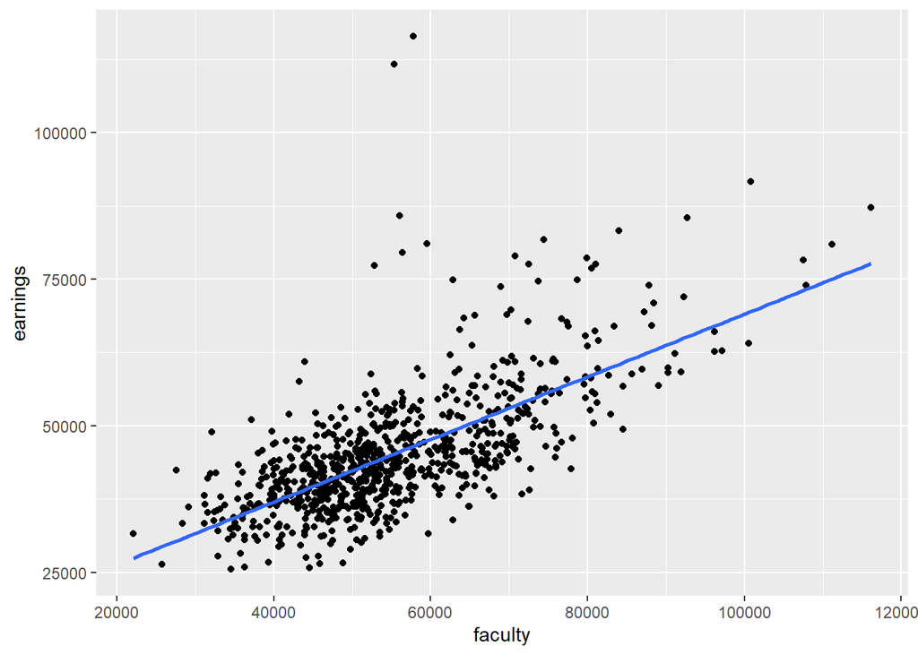

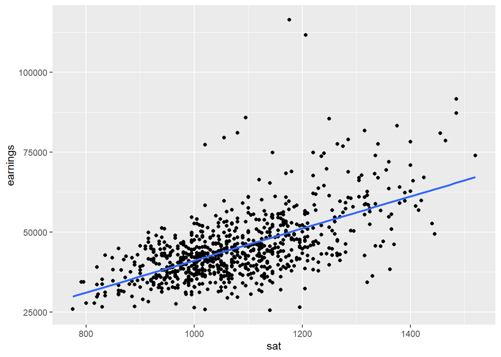

### Scene 4

**Prompt:** Now let’s quantify these relationships between the two explanatory variables and the outcome variable. Fit a multiple regression model for `earnings` using `sat` and `faculty`. Write a bullet point interpreting each of the three values in the estimate column.

```
##
## Call:
## lm(formula = earnings ~ sat + faculty, data = x)
##
## Residuals:
##    Min     1Q Median     3Q    Max
## -19939  -4334   -932   3398  67949
##
## Coefficients:
##               Estimate Std. Error t value Pr(>|t|)
## (Intercept) -2.591e+03  2.293e+03  -1.130    0.259
## sat          2.448e+01  2.683e+00   9.125   <2e-16 ***
## faculty      3.854e-01  2.563e-02  15.038   <2e-16 ***
## ---
## Signif. codes:  0 '***' 0.001 '**' 0.01 '*' 0.05 '.' 0.1 ' ' 1
##
## Residual standard error: 7528 on 794 degrees of freedom
## Multiple R-squared:  0.5058, Adjusted R-squared:  0.5045
## F-statistic: 406.3 on 2 and 794 DF,  p-value: < 2.2e-16
```

```
## # A tibble: 3 x 5
##   term         estimate std.error statistic  p.value
##   <chr>           <dbl>     <dbl>     <dbl>    <dbl>
## 1 (Intercept) -2591.    2293.         -1.13 2.59e- 1
## 2 sat            24.5      2.68        9.12 5.82e-19
## 3 faculty         0.385    0.0256     15.0  3.71e-45
```

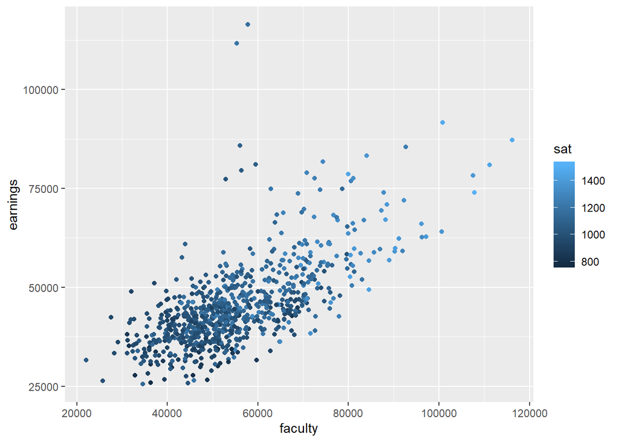

Sat has a positive value, so as SAT score increases by 1 point estimated earnings increases 24.48 Faculty has a positive value so as median faculty salary increases by 1, estimated median earnings increases by 0.38 Intercept represents the expected earnings with 0 SAT and 0 faculty salary - it has mathematical but not interpretative significance

### Scene 5

**Prompt:** Imagine that you are the university president. There’s a global pandemic that is causing serious financial damage to the school endowment, and in response, you want to cut the financial aid budget. However, because many academically talented students will go to whichever school gives them the best financial aid package, slashing the financial aid budget will cause the average SAT score to decrease from 1400 to 1300. Apply the Rubin Causal Model to estimate the causal effect of SAT scores on students’ median earnings. Write down the units, the treatments, and the outcomes. Define the causal effect of `sat` on median earnings. What is the fundamental problem of causal inference? What **must** you assume for this causal model to make a causal claim?

units: individual colleges treatments: 100 point downward shock to avg SAT score (caused by cut of financial aid budget) outcomes: median earnings 10y later

causal effect of sat on median earnings: Difference between what median earnings would have been under the old policy (and SAT score) relative to what the median earnings will be under the new policy (and SAT score)

Problem: Cant observe both worlds - treatment and no treatment for the same unit

Assumption for this to be causal: There are no other confounding variables which are correlated with the treatment and the outcome other than SAT which differ between the treatment and control sub populations

### Scene 6

**Prompt:** Let’s make predictions based on our regression model for two schools, School A and School B with different average faculty salaries. What would each school’s students’ median earnings be under different average SAT scores?

[output not shown]

### Scene 7

**Prompt:** Now that we have our regression model using two numerical explanatory variables, let’s find the fitted values and residuals for the model using `augment()`. What do the fitted values and residuals mean, in terms of where they appear in a fitted line graph?

### Scene 8

**Prompt:** Now that we have explored the relationships between two numerical explanatory variables and the outcome variable, let’s look at a model that involves using one categorical variable `public` and one numerical explanatory variable `price` to explain the median earnings variable. We will explore a specific type of multiple regression model called an **interaction model** in this scene. `public` is 0 if the school is private and 1 if it is not.

First, fit the interaction regression model using the `lm()`. Then, retrieve the regression estimates, including the upper and lower bounds for the confidence intervals. Interpret the meaning of each of the estimates.

### Scene 9

**Prompt:** In the previous scene, we generated the confidence intervals using `tidy(conf.int = TRUE)` (if you haven’t, go back and do so now). Let’s check those confidence intervals by doing our own bootstrapping. Set `reps = 100` to save processing time. Hints: `unnest()`, `group_by()`, and `summarize()` are useful here.

How do the confidence intervals from bootstrapping compare to the ones we found in the previous scene? Provide a one sentence Bayesian interpretation and a one sentence Frequentist interpretation.

### Scene 10

**Prompt:** Now that we have our regression model using one numerical and one categorical explanatory variables, let’s visualize the interaction model using `ggplot2`. Set the colors to represent public vs. private xs. Hint: Be sure to make the `public` variable into a factor first.